# TD 2 : Régression logistique (R)

Années universitaires 2025–2026 et 2026–2027 • Parcours Économie de la santé & Développement durable

Pierre Beaucoral

2026-10-16

> Ce TD reprend l’exemple et le dictionnaire de variables (`age, ed, employ, address, income, debtinc, credebt, othdebt, default`) décrits dans la ressource d’origine.  
> Données à récupérer : **`bankloanT.xls`** (télécharger).

**Packages utilisés** : `tidyverse`, `readxl`, `janitor`, `broom`, `ResourceSelection`, `pROC`, `gt`, `ggplot2`.

# 1 Rappel de cours : Modèles Logit et Probit

## 1.1 Quand utiliser ces modèles ?

La **régression logistique** et la **régression probit** sont utilisées lorsque la variable à expliquer est **binaire** :

$Y_i \in {0,1}$

- Exemple : défaut de paiement / pas de défaut
- Objectif : estimer la **probabilité** $P(Y_i = 1 \mid X_i)$ en fonction de caractéristiques $X_i$

Les variables explicatives peuvent être **quantitatives ou qualitatives**.

## 1.2 Pourquoi ne pas utiliser une régression linéaire ?

Une régression linéaire classique :

$Y_i = \beta_0 + \beta_1 X_i + \varepsilon_i$

peut donner des valeurs **prédites hors de [0, 1]**, ce qui est absurde pour une probabilité.

Il faut donc introduire une **fonction de lien** qui transforme l’intervalle (0, 1) en $\mathbb{R}$.

## 1.3 Fonction de lien du modèle Logit

$\text{logit}(p) = \ln\left(\frac{p}{1 - p}\right) \quad \text{et} \quad p = \frac{e^{x}}{1 + e^{x}} = \frac{1}{1 + e^{-x}}$

Le modèle s’écrit :

$\text{logit}(P(Y_i = 1)) = \beta_0 + \beta1 X{i1} + \dots + \beta_p X{ip}$

Les coefficients $\beta_j$ s’interprètent via les **odds-ratios** : $OR_j = e^{\beta_j}$

## 1.4 Fonction de lien du modèle Probit

Le modèle Probit suppose qu’il existe une **variable latente** $Y_i^*$ telle que :

$Y_i^* = \beta_0 + \beta1 X{i1} + \dots + \beta_p X{ip} + \varepsilon_i \quad \text{avec} \quad \varepsilon_i \sim \mathcal{N}(0,1)$

et on observe :

$Y_i = 1 \text{ si } Y_i^* > 0$

d’où :

$P(Y_i = 1) = \Phi(\beta_0 + \beta_1 X_i)$ où $\Phi$ est la fonction de répartition de la loi normale centrée réduite.

## 1.5 Comparaison graphique des liens Logit et Probit

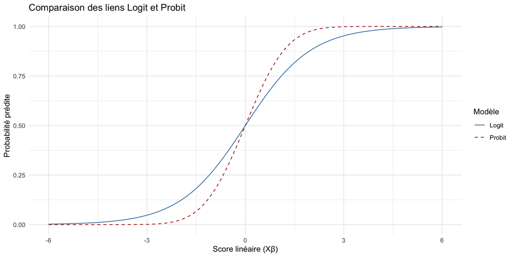

Figure 1: Comparaison des fonctions de lien Logit et Probit

```r
library(ggplot2)

x <- seq(-6, 6, length.out = 200)

df_link <- data.frame( x = x, Logit = 1 / (1 + exp(-x)), Probit = pnorm(x) )

ggplot(df_link, aes(x = x)) + geom_line(aes(y = Logit, color = "Logit")) + geom_line(aes(y = Probit, color = "Probit"), linetype = 2) + scale_color_manual(values = c("Logit" = "steelblue", "Probit" = "firebrick")) + labs( title = "Comparaison des liens Logit et Probit", x = "Score linéaire (Xβ)", y = "Probabilité prédite", color = "Modèle" ) + theme_minimal()
```

## 1.6 Interprétation économique

- **Logit** : privilégié quand on interprète les coefficients en termes d’odds-ratios (très courant en santé et sciences sociales).
- **Probit** : privilégié en économie microéconométrique, car il se relie naturellement à un modèle de variable latente et au Tobit.

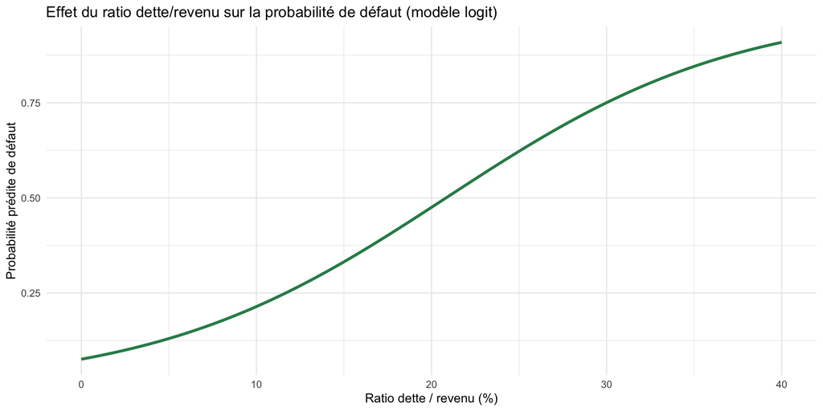

Figure 2: Exemple : probabilité prédite de défaut selon le ratio dette/revenu

```r
x <- seq(0, 40, length.out = 200)
beta0 <- -2.5; beta1 <- 0.12
p_hat <- 1 / (1 + exp(-(beta0 + beta1 * x)))

df_ex <- data.frame(debt_income = x, p_hat = p_hat)

ggplot(df_ex, aes(debt_income, p_hat)) +
geom_line(color = "seagreen4", linewidth = 1.2) +
labs(
title = "Effet du ratio dette/revenu sur la probabilité de défaut (modèle logit)",
x = "Ratio dette / revenu (%)",
y = "Probabilité prédite de défaut"
) +
theme_minimal()
```

**Interprétation :**

→ Lorsque le ratio dette/revenu augmente, la probabilité prédite de défaut croît de manière sigmoïde : faible au départ, elle augmente rapidement autour de la zone moyenne, puis se stabilise.

### 1.6.1 Résumé comparatif

| Caractéristique | Logit | Probit |
| --- | --- | --- |
| Fonction de lien | logit(p) = log(p/(1−p)) | Φ⁻¹(p) |
| Distribution implicite des erreurs | Logistique | Normale centrée réduite |
| Interprétation des coefficients | Odds-ratios | Z-scores latents |
| Usages typiques | Santé, sociologie | Économie, finance |
| Résultats empiriques | Quasi identiques (β_logit ≈ 1.6 β_probit) |  |

> **À retenir :** Logit et Probit sont deux manières voisines de modéliser une probabilité binaire. Le choix entre les deux est souvent une question de convention disciplinaire ou d’interprétabilité des coefficients.

# 2 Questions TD

## 2.1 Corrections publiées après la séance

Les questions du TD sont dans l’énoncé. Les slides de correction seront mises en ligne après la séance.